# Web Scraping

André Pignata

March 23, 2018

# Web Scraping - de requests à Selenium

## Quem estou, porque sou, onde vim?

- André Luiz Martins Pignata
  - gmail@andrepignata.com.br
- Bacharel em Ciências da Computação pela UFSCAR.
  - Programador de Clipper, Delphi, PHP, PL/SQL, R e Python
  - Com sidequests em Javascript e P4A.
- Analista de Sistemas do Departamento de Economia
  - Auxilio alunos e docentes em pesquisas
- Anapropegua da GEDANKEN
  - Impacto em gestão pública utilizando *Big Data* e *IA*

## Ideia por trás do webscrapping

- A técnica de Web scraping consiste em extrair dados diretamente de páginas ou serviços online
- Vamos ver 3 técnicas diferentes para obter os dados
- Alguns sites exigirão muito mais trabalho de codificação, especialmente os sites que utilizam **AJAX**

### Fluxo de data Science

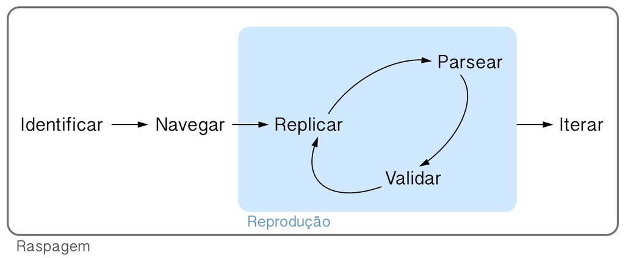

## Princípios básicos

- Identificar
- Navegar
- Replicar
- Parsear
- Validar

## Ferramentas

- Python
- Virtualenv (anaconda)
- Pacotes
  - conda install -c conda-forge selenium
  - conda install spyder pandas beautifulsoup4 sqlalchemy psycopg2
- Spyder versus Jupyter

## Técnicas/bibliotecas para webscrapping

- Requests
  - IBGE Cidades
  - Google geocode api
- Beautifulsoup
  - Americanas.com.br
- Selenium
  - CVM

## Requests

- IBGE Cidades
  - Cuidados ao fazer webscrap em sites (DoS)
  - Olhando o site (torcendo para ele não estar quebrado)
  - Olhando o script
    - Alternativa: dados_govbr.py
- Google geocode api
  - [Google geocode api](https://developers.google.com/maps/documentation/geocoding/intro?hl=pt-br)
  - Olhando o retorno no browser
  - Json
  - Olhando o script

## Beautifulsoup

- Americanas.com.br
  - Principais funções do Beautifulsoup
- Lattes
  - Parse do header (Form data e Sublime Text - exp regular - 42)
  - (.*): (.*) -> ‘\1’:‘\2’,
  - SQL Injection
  - Paginação
  - Passagem de parâmetros pela URL (get)

## Selenium

- [Material para consulta](https://goo.gl/QLdDbo)
- Olhando o script para entender
- CVM
  - estratégia de paginação
  - pontos de reinício